# Bayes-DL Covid-19

Stefano Cabras

2021-12-05 23:09:22

# Manuscript

The model here implemented is documented in

Stefano Cabras, A Bayesian-Deep Learning Model for Estimating COVID-19 Evolution in Spain, *Mathematics*, **9**(22), 2921, 2021. (https://doi.org/10.3390/math9222921)

# Data preparation

Data are downloaded from https://cnecovid.isciii.es/covid19/#documentaci%C3%B3n-y-datos. Such data are supposed to represent values day by day of COVID-19 incidence for regions (CCAA) in Spain.

```r
ccaa.lab=c("AN", "AR", "AS", "CB", "CE", "CL", "CM", "CN", "CT",
           "EX", "GA","IB", "MC", "MD", "ML", "NC","PV", "RI", "VC")
cvirus.ccaa=read.table("https://cnecovid.isciii.es/covid19/resources/casos_diag_ccaadecl.csv",
                          sep = ",", header = T)
#cvirus.ccaa=cvirus.ccaa[cvirus.ccaa$fecha<="2021-10-18",]
maxr=max(which(cvirus.ccaa$fecha==max(cvirus.ccaa$fecha)))
cvirus.ccaa$ccaa_iso=factor(cvirus.ccaa$ccaa_iso)
cvirus.ccaa=data.frame(region=cvirus.ccaa$ccaa_iso,
                  day=as.Date(as.character(cvirus.ccaa$fecha),
                              format="%Y-%m-%d"),
                  cases=cvirus.ccaa$num_casos)
pop=read.table("demcca.csv",header = TRUE,sep=";")
pop=data.frame(region=pop$CCAA,pop=pop$pob)[1:19,]
pop=pop[order(pop$region),]
pop$w=pop$pop/sum(pop$pop)
```

The statistical unit is the day and variables are cumulative cases of the past 14 days up to the day in each one of the 19 Spanish regions (CCAA).

```r
cvirus.ccaa.fat=dcast(cvirus.ccaa,formula = day~region,value.var = "cases")
for(j in 2:ncol(cvirus.ccaa.fat)){
  y=cvirus.ccaa.fat[,j]
  y=c(rep(0,13),y)
  y=cumsum(y)
  y=y[14:length(y)]-y[1+(0:(length(y)-14))]
  cvirus.ccaa.fat[,j]=as.integer((y/pop$pop[pop$region==colnames(cvirus.ccaa.fat)[j]])*100000)
}

cvirus=cvirus.ccaa.fat
last.observed=max(cvirus$day)
dim(cvirus)
```

```
## [1] 685  20
```

These are daily cumulative 14 days incidence :

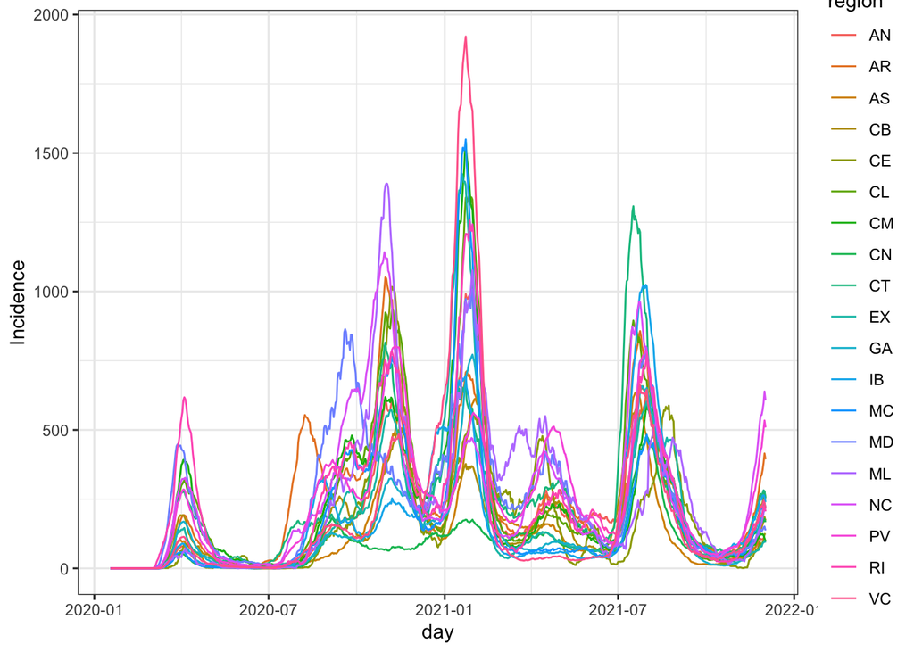

```r
meltdat=melt(cvirus,id="day",variable.name = "region",
             value.name = "Incidence")
p=ggplot(meltdat, aes(x =day, y = Incidence,color=region))+
  geom_line()+
  theme(axis.text.x = element_text(angle = 90,size=rel(0.8)))+ theme_bw()
p
```

# Model

$$P=Pr(Y_{ts}\leq y|\mathcal{F_{t-1}}),$$

where $\mathcal{F_{t-1}}$ represents the process filtration up to the day before over all possible sequences (over all possible $s$).

If $P$ were known then it allows to predict: 1. covid-19 evolution conditionally on the paste; 2. spillover effects along regions and along with features and thus answer, to question of the kind: what will happen if in some of the Spanish region covid-19 start to spread out or disappear? 3. Which are the most connected regions? For instance, who much it is important to control cases more in the Canary Islands or Madrid in terms of variations of induced more cases overall Spain?

We attempt to estimate $P$ into two steps: 1. by approximating the mode of $Y_{ts}$ using a Deep Learning approach for sequences, with particular attention to LSTM architectures; 2. by finally estimating $P$ according to an i.i.d. Poisson model for each $t$ and $s$ where the prior on the intensity is given by the DL estimation which provides the mean along with the error of the DL model which provides the prior intensity variance.

## LSTM Estimation

LSTM models are a special instance of recurrent neural networks, see https://en.wikipedia.org/wiki/Long_short-term_memory.

### Model train and test

```r
est.lstm=function(dat,test.from=max(cvirus$day)+1){
  unlink("dlio", recursive = TRUE)
  dir.create("dlio")
  ii=dat[,1]<test.from
  write.table(dat[ii,-1],file="dlio/civinput.csv",
              sep=",",row.names = FALSE)
  write.table(dat[,-1],file="dlio/civinput-test.csv",
              sep=",",row.names = FALSE)
  py_set_seed(17)
  py_run_file("dl.py") # Here is the LSTM model used
}
```

All observations aftert `test.from` are for test and not for train.

```r
collect.lstmoutout=function(datobs,testset=FALSE){
  allres=allerror=allres.bayes=NULL
  for(i in 1:max_delay){
    if(testset){
        preds <- read.csv(paste("dlio/civout-test",i,".csv",sep=""),sep=",")[-1]
    }else{
        preds <- read.csv(paste("dlio/civout",i,".csv",sep=""),sep=",")[-1]
    }
    preds[preds<0]=0
    dd=(datobs$day)[(nrow(datobs)-nrow(preds)+1):nrow(datobs)]
    preds$day=dd+i-1
    preds$delay=i
    preds$type="lstm.pred"
    mm=match(preds$day,datobs$day)
    error=datobs[mm,-1]-preds[,1:19]
    error$delay=i
    error$day=datobs$day[mm]
    allres.bayes=rbind(allres.bayes,cbind(preds,datobs[mm,]))
    allres=rbind(allres,preds)
    allerror=rbind(allerror,error)
  }
  allres=rbind(allres,data.frame(datobs,type="observed",delay=0))
  allres=melt(allres,id.vars=c("day","delay","type"),
              variable.name = "region",value.name = "cases")
  allerror=melt(allerror,id.vars=c("day","delay"),
                variable.name = "region",value.name = "error")
  return(list(allres.bayes,allres,allerror))
}
```

Here we estimate twice the model: the first for evaluating performance on test set and the second for the final analysis.

```r
max_delay=length(list.files(path = "dlio",pattern = "civout-test"))
est.lstm(cvirus,test.from=last.observed-max_delay) # Model evaluation on Test set
max_delay=60
tt=collect.lstmoutout(cvirus,testset = TRUE)
allres.test=tt[[2]]
allerror.test=tt[[3]]
allres.bayes.test=tt[[1]]

est.lstm(cvirus) # Now we use all data for the rest of analysis
tt=collect.lstmoutout(cvirus)
allres=tt[[2]]
allerror=tt[[3]]
allres.bayes=tt[[1]]
```

The model is learning from the data because the prediction error decreases.

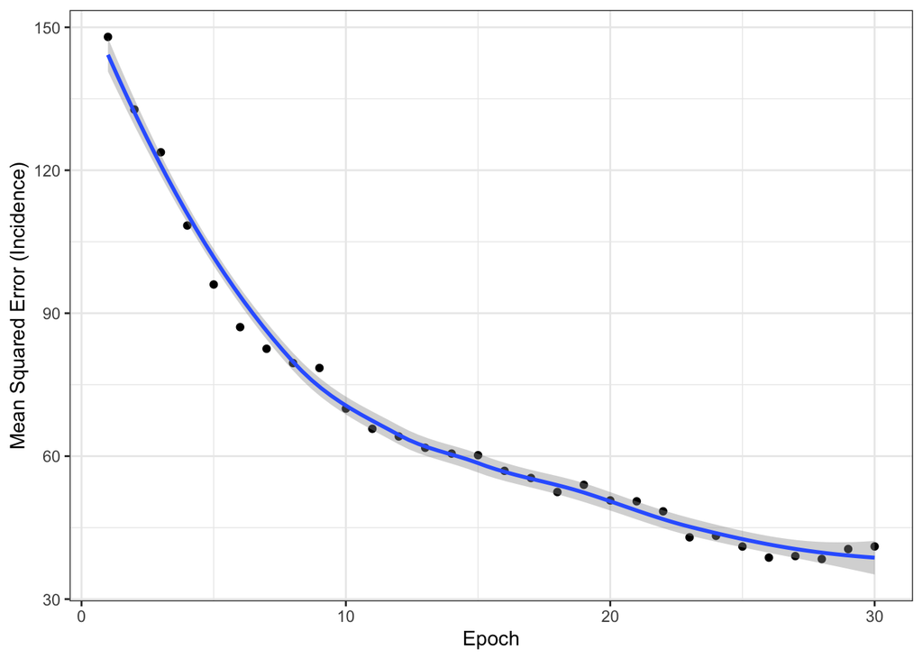

```r
history=read.csv("dlio/history.csv")
history=history*sd(unlist(cvirus[,-1]))
ggplot(history,aes(x=1:nrow(history),y=val_loss))+
  geom_point()+geom_smooth()+xlab("Epoch")+
  ylab("Mean Squared Error (Incidence)")+ theme_bw()
```

These are the errors depending on how many days before was made the prediction (delay) and the region (some region is more easy to be predicted than others). There are the LSTM errors (prior variances):

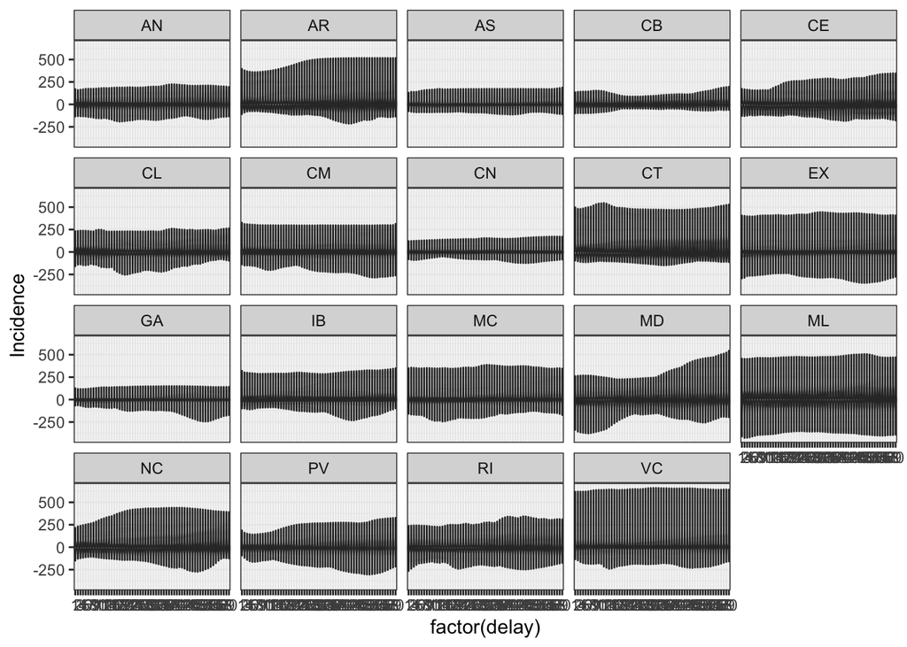

```r
ggplot(allerror,aes(x=factor(delay),y=error))+
  facet_wrap(. ~ region)+geom_violin()+ ylab("Incidence")+ theme_bw()
```

These are the LSTM predictions (prior means):

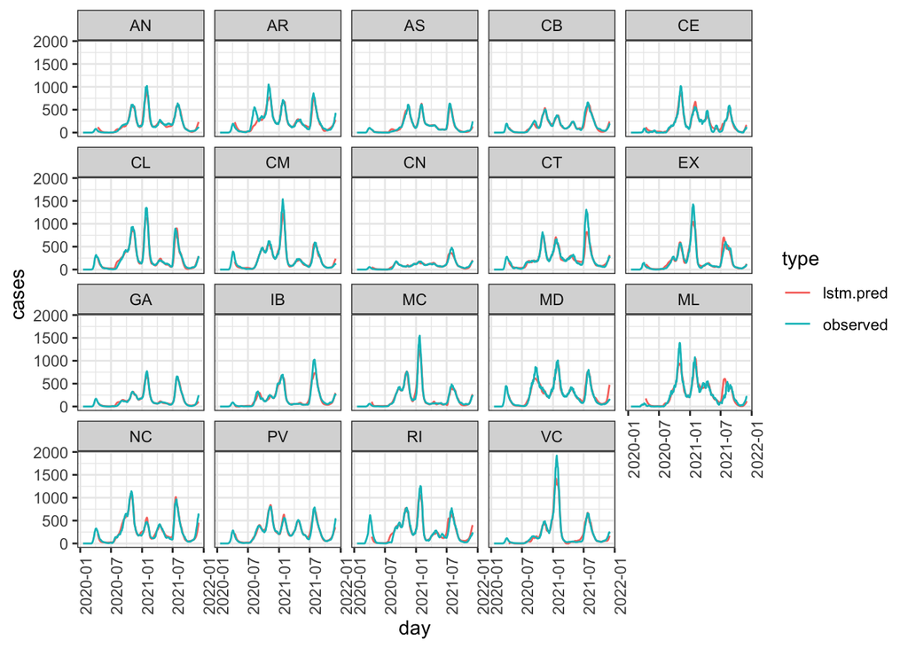

```r
ggplot(subset(allres,(delay%in%c(0,1))),
          aes(x=day,y=cases,color=type))+facet_wrap(. ~ region)+geom_line()+ theme_bw() +
  theme(axis.text.x = element_text(angle = 90,size=rel(1)))
```

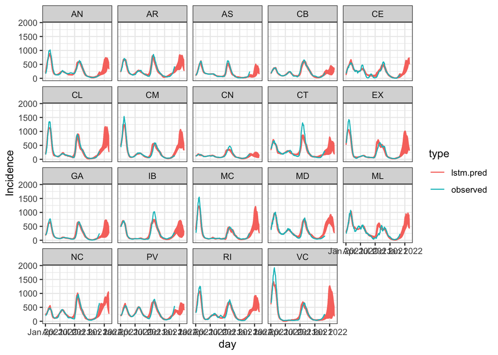

```r
ggplot(subset(allres,day>as.Date("2021-01-01")),aes(x=day,y=cases,color=type))+
  facet_wrap(. ~ region)+geom_line()+
  theme(axis.text.x = element_text(angle = 90,size=rel(0.8)))+ ylab("Incidence")+ theme_bw()
```

Such output contains a guess of the process filtration $\mathcal{F_{t-1}}$ in $P$.

# Bayesian model

To account for prediction uncertainty we assume that the LSTM prediction and the corresponding errors act as an expert who elicits the mean of the Poisson (the LSTM prediction) along with its variance (the LSTM mean squared error). The variances are calculated conditionally to the region and the number of days ahead in the prediction (delay).

The Negative Binomial Bayesian Model predictive posterior is calculated here. In particular the model reports the posterior median along with 90% Credible Intervals.

```r
bayes.pred=function(allres.bayes,no.obs=FALSE){
  preds=melt(data.frame(allres.bayes[,1:21]),
             id.vars = c("day","delay"),value.name = "cases",
             variable.name = "region")
  obs=melt(data.frame(allres.bayes[,c(20,24:42)]),id.vars = "day",
           value.name = "cases",variable.name = "region")

  lstm.var=data.frame(error=(preds$cases-obs$cases)^2,delay=preds$delay,region=preds$region)
  lstm.var=aggregate(lstm.var$error,by = list(delay=lstm.var$delay,region=lstm.var$region),mean,na.rm=TRUE)
  prior.var=apply(preds[,2:3],1,function(xx) lstm.var$x[(lstm.var$delay==as.numeric(xx[1]))&(lstm.var$region==as.character(xx[2]))])
  ii=is.na(obs$cases)|no.obs
  a=preds$cases^2/prior.var # Prior Gamma a parameter
  b=preds$cases/prior.var # Prior Gamma b parameter
  p=(b+1)/(b+2) # Predictive posterior p parameter
  p[ii]=b[ii]/(b[ii]+1)
  oo=obs$cases
  oo[ii]=0
  size=a+oo # Predictive posterior size parameter
  post.pred.summary=t(apply(cbind(size,p),1,function(x) qnbinom(c(0.05,0.5,0.95),size=x[1],prob=x[2])))
  colnames(post.pred.summary)=c("Inf90","median","Sup90")
  final.res=data.frame(day=preds$day,delay=preds$delay,
                       region=preds$region,
                       lstm=preds$cases,observed=obs$cases,post.pred.summary)
  # Only best prediction for that unknown day
  diff.pred=preds$day-max(allres.bayes[,23],na.rm=TRUE)
  final.res=final.res[(diff.pred<=0)|((diff.pred>0)&(preds$delay-diff.pred<=1)),]
  return(final.res)
}
final.res=bayes.pred(allres.bayes)
```

# Results on available data

These are the prediction of the incidence given the observed data: posterior predictive and prior predictive (according to the LSTM “expert” elicitation).

## Incidence by region

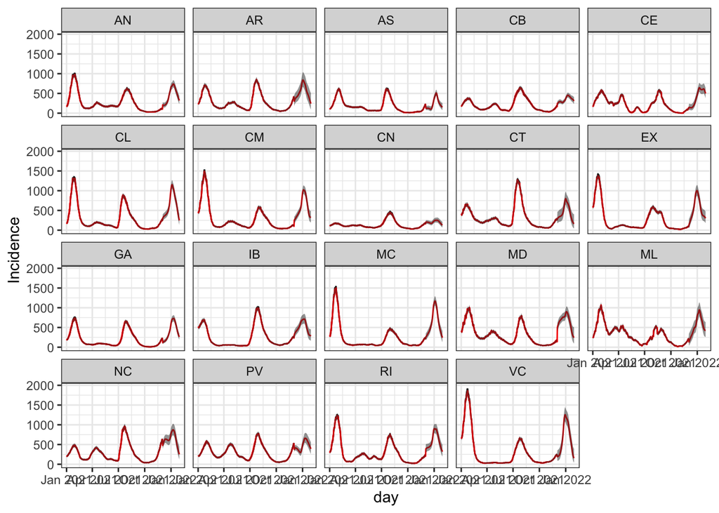

```r
toplot=subset(final.res,day>as.Date("2021-01-01"))
toplot=toplot[toplot$delay>=1,]
ggplot(toplot,aes(x=day,y=observed))+geom_line()+
geom_line(aes(x=day,y=median),colour="red")+
  geom_ribbon(aes(x=day,ymin=Inf90,ymax=Sup90),alpha = 0.5)+
              facet_wrap(. ~ region)+
              theme(axis.text.x = element_text(angle = 90,size=rel(0.8)))+
  ylab("Incidence")+ theme_bw()
```

```r
datatable(toplot[is.na(toplot$observed),],rownames = NULL)
```

| day | delay | region | lstm | observed | Inf90 | median | Sup90 |
| --- | --- | --- | --- | --- | --- | --- | --- |
| 2021-12-03 | 2 | AN | 212 |  | 154 | 210 | 277 |
| 2021-12-04 | 3 | AN | 208 |  | 150 | 206 | 273 |
| 2021-12-05 | 4 | AN | 204 |  | 146 | 202 | 269 |
| 2021-12-06 | 5 | AN | 202 |  | 144 | 200 | 267 |
| 2021-12-07 | 6 | AN | 201 |  | 143 | 199 | 266 |
| 2021-12-08 | 7 | AN | 201 |  | 143 | 199 | 267 |
| 2021-12-09 | 8 | AN | 202 |  | 143 | 200 | 268 |
| 2021-12-10 | 9 | AN | 204 |  | 144 | 202 | 271 |
| 2021-12-11 | 10 | AN | 208 |  | 148 | 206 | 276 |
| 2021-12-12 | 11 | AN | 213 |  | 152 | 211 | 282 |

[output cut: 1111 more lines]

## Incidence for Spain

The same as above but for all Spain in which regions are weighted according to their population.

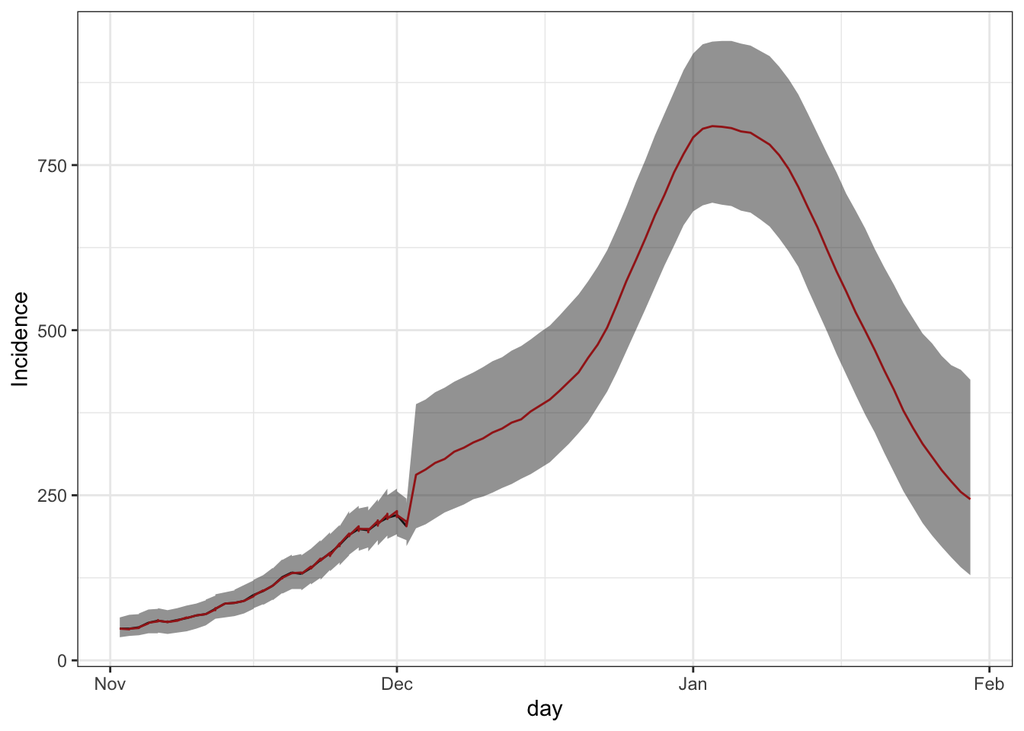

```r
final.res.spain=round(final.res[c("observed","Inf90","median","Sup90")]*pop$w[final.res$region],0)
final.res.spain=aggregate(final.res.spain,by=list(day=final.res$day,delay=final.res$delay),sum)

toplot=subset(final.res.spain,day>as.Date("2021-11-01"))
toplot=toplot[toplot$delay>=1,]
pmax=ggplot(toplot,aes(x=day,y=observed))+geom_line()+
  geom_line(aes(x=day,y=median),colour="red")+
  geom_ribbon(aes(x=day,ymin=Inf90,ymax=Sup90),alpha = 0.5)+
              theme(axis.text.x = element_text(angle = 90,size=rel(0.8)))+
  ylab("Incidence")+ theme_bw()

pmax
```

```r
datatable(toplot[is.na(toplot$observed),],rownames = NULL)
```

| day | delay | observed | Inf90 | median | Sup90 |
| --- | --- | --- | --- | --- | --- |
| 2021-12-03 | 2 |  | 200 | 281 | 388 |
| 2021-12-04 | 3 |  | 206 | 289 | 395 |
| 2021-12-05 | 4 |  | 215 | 299 | 406 |
| 2021-12-06 | 5 |  | 224 | 305 | 413 |
| 2021-12-07 | 6 |  | 230 | 316 | 422 |
| 2021-12-08 | 7 |  | 236 | 322 | 429 |
| 2021-12-09 | 8 |  | 244 | 330 | 436 |
| 2021-12-10 | 9 |  | 248 | 336 | 444 |
| 2021-12-11 | 10 |  | 254 | 345 | 453 |
| 2021-12-12 | 11 |  | 261 | 351 | 459 |

[output cut: 49 more lines]